# Nova Scotia Employee Absenteeism - in Python

Chris Selig

16 August, 2020

# Summary

Way back in August 2017 I started to apply R to working with data and one of my early projects was to explore the Nova Scotia (NS) Government employee absentee [data.](https://data.novascotia.ca/Public-Service/Nova-Scotia-Government-Employee-Absenteeism/3kpf-veux) You can see the original post [here.](https://bidamia.ca/post/nova-scotia-government-employee-absentee-analysis/)

I am revisiting this analysis because I am now learning python and I got tired of doing courses and wanted to apply what I learned so far. Also, there is now a few years more worth of data.

Goal: The goal is to perfrom a mini exploratory analysis of the data.

The code for this analysis can be found on my [Github page.](https://github.com/chrisselig/ns_employee_absenteeism_python)

# The Data

As before, I will start with an exploratory analysis of the data, but first, let’s review the columns in the dataset.

1. absence_date: The date of absence for the employee
2. absence_hours: The number of hours the employee was absent
3. absence_type: The reason for the absence
4. absence_type_category: The absence reasons are grouped into standard categories
5. age_cohort_on_absence_date: The age range of the employee, the day they were absent
6. employee_type: Whether the employee was union, or non-union
7. gender: The gender of the employee

In total, there are 7 columns and 3,568,910 rows with data spanning from April 1st 2014 to March 31st, 2020.

’

| absence_date | absence_type_category | absence_type | absence_hours | employee_type |
| --- | --- | --- | --- | --- |
| 2014-04-01 | Short Term Illness | Short Term Illness | 8.00 | Union |
| 2014-04-01 | Short Term Illness | Short Term Illness | 9.00 | Union |
| 2014-04-01 | Short Term Illness | Short Term Illness | 9.00 | Union |
| 2014-04-01 | General Illness | General Illness | 7.75 | Union |

’

# Exploratory Analysis

Originally, I started by taking a look at the total number of days absent which not only did not account for the fact that the people were not always absent for full days but I also only looked at total absences. A more realistic approach would have been to standardize absences per 100 people or absence hours per 100 people. Unfortunately, I cannot find any information on how many people are employed by the NS government so I will continue with counts alone.

Below is the count of absences by age group. Interestingy enough, the initial trend did not hold. When I looked at this a few years ago, the 50-54 age category had the most absences. Now it is the 55-59 crowd. I wonder if that is because the 50 - 54 crowd could now be in the 55 - 59 crowd?

At the bottom of the scale, the under 25 crowd still has the lowest absences. Either way, I do not want to infer much from this data because I have no idea of the counts of each employee cohort.

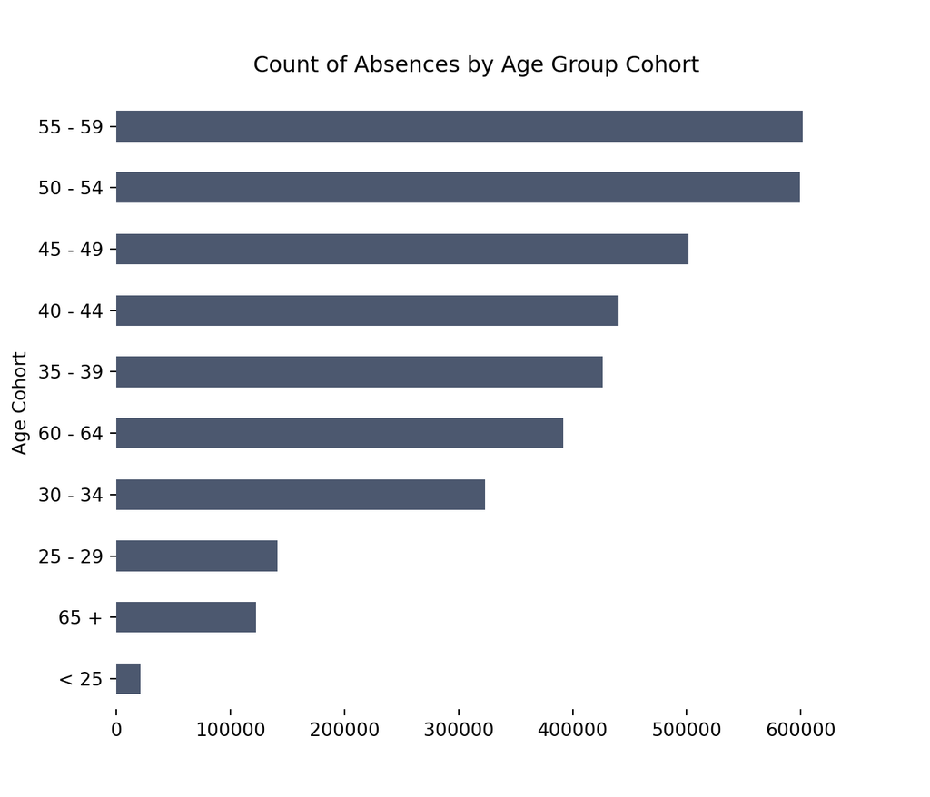

Moving on, let’s take a look at the counts of absences by category.

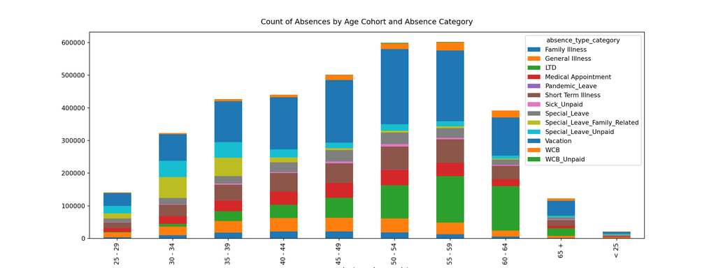

The first thing I noticed about this plot was that there is a new category: Pandemic_Leave. At the time of writing (August 2020), the world is still experiencing COVID-19 and alot of places in Canada are still working from home, evening though restrictions have been loosening across the country.

Next, I will explore absences by month.

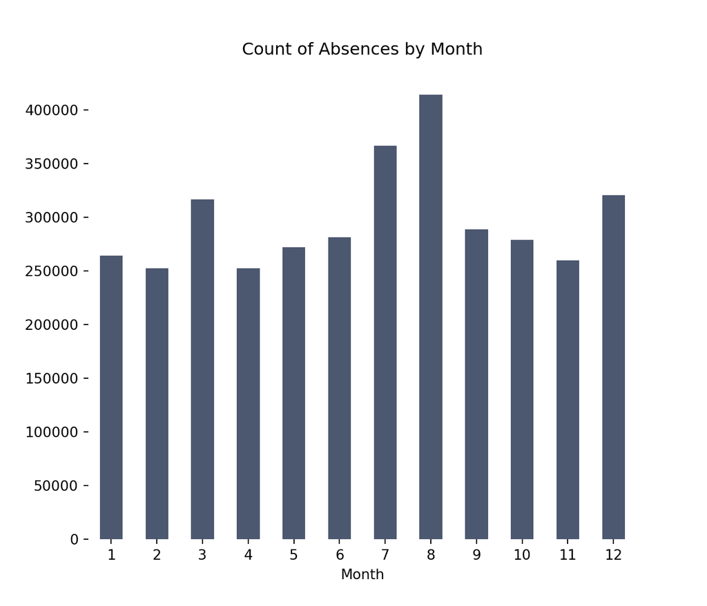

As before, there is a spike in March, July, August and December. March spiked probaby relate to it being March break for schools. Parents often take time off for vacationing with their children at this time. July and August are the most popular months for taking vacation for most people while December has the Christmas holidays where people tend to take time off to spend with family.

The last section for the exploratory analysis will take a look at absences by employee type. The Nova Scotia government has both unionized and non-union employees. Below are the counts.

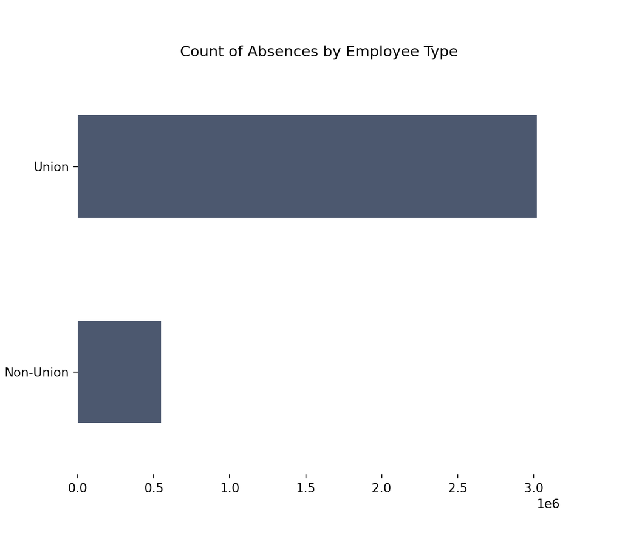

The number of absences by unionized employees is approximately 5 times the amount of non-union. Without employee counts by type though, we should not read too much into this.